# Lecture: Programming and modeling in Stan: extensions

## 1 Model blocks

### 1.1 Main model blocks for Bayesian inference

As we established in the last session, a Stan program for *Bayesian inference* must include the following model blocks:

1. **Data**: Declare all known quantities, including data types, dimensions, and constraints
2. **Parameters**: Declare unknown ‘base’ quantities, including storage types, dimensions, and constraints
3. **Model**: Declare and specify local variables (optional); specify sampling statements for priors and likelihood

### 1.2 Other model blocks

In this session, we want to pay closer attention to the four other [model blocks](https://mc-stan.org/docs/reference-manual/blocks.html):

1. **Functions**: Declare user written functions
2. **Transformed Data**: Declare and define/transform data inputs
3. **Transformed Parameters**: Declare and transform parameters
4. **Generated Quantities**: Declare and generate derivative quantities

### 1.3 “Trivial” tasks

Stan is a full-blown statistical programming language. We can therefore accommodate tasks like data pre-processing and estimate post-processing (QOI generation) as part of our Stan models.

As `rstan` users, however, the question with many of these tasks is whether we cannot accommodate them more efficiently in R before or after estimation.

### 1.4 Some tasks that *can* be implemented as part of a Stan program

- Data standardization:
  - We could first define a function that standardizes our variables in the `functions` block and then apply it to the data in the `transformed data` block.
  - But we can equally standardize the data in R and pass the standardized variables to Stan.
- Transformed parameters:
  - Last session, we sampled the linear predictor `eta` as a global variable in the `transformed parameters` block, which we (could have) sampled.
  - We could have equally defined `eta` as a temporary local variable in the `model block`, where it would have been discarded after each iteration…
  - …and recovered it post-estimation in R per $\mathbf{X\beta}$ if desired.
- Quantities of interest:
  - We can use the `generated quantities` block to calculate quantities of interest (expected values, average marginal effects, etc.) or to implement posterior predictive checks.
  - But we can equally do this just in R using the posterior draws and the data.

### 1.5 My recommendation

There is nothing wrong with accommodating such “trivial tasks” in Stan. But several efficiency concerns speak against it:

- If you are more proficient in R than in Stan, implementing tasks in Stan that you could easily perform in R is time not wisely invested.
- If you need to adjust transformations on a rolling basis (e.g., changing covariate scenarios for your quantities of interest), it is wise to separate estimation from post-estimation work.
- Computational resources can be *expensive*.
  - Once your Stan models get too big to run on local machines, efficiency is money (literally).
  - Minimize run times by restricting your Stan model to essential tasks (i.e., estimation).
  - Limit your RAM usage to what’s necessary; do not sample (transformed) parameters you do not need.
- Keeping your Stan model program slim makes debugging easier.

### 1.6 Other model blocks: Essential tasks

There are, however, some essential tasks that should or must be accommodated in Stan:

- Functions needed for estimation (e.g., custom log-density functions)
- Transformed parameters that are of primary interest
  - In many instances, it is computationally *more* efficient to specify priors for “raw parameters” and transform these before they enter the likelihood.
  - In these cases, your primary concern should be sampling and diagnosing the transformed parameters.

## 2 Extensions

### 2.1 Example 1: Weighted likelihood

- Weights ensure that observations do not contribute to the log-likelihood equally, but proportionally to their idiosyncratic weights.
- Let’s incorporate this feature into our Stan program for the linear model.
- The hack requires two things:
  - the definition of a new function
  - Two minor, single-line modifications: One in the `data`, one in the `model` block

### 2.2 The unweighted normal log-likelihood

We first need to understand the built-in function for the unweighted log-likelihood, `normal_lpdf`.

`normal_lpdf` defines the log of the [normal probability density function](https://en.wikipedia.org/wiki/Normal_distribution) (pdf) and sums across the resulting values of all observations, which returns a scalar:

$$\mathtt{normal\_lpdf(y | eta, sigma)} =
\sum_{i=1}^{N} - \frac{1}{2} \log (2 \pi \sigma^2) \Big(
\frac{y_i-\eta_i}{\sigma}\Big)^2$$

### 2.3 The weighted normal log-likelihood

Why is this problematic?

- To include weights, we need to weight every single entry in the log normal pdf *prior to* aggregation.
- So, we need a length-$N$ vector of $\mathtt{normal\_lpdf}$ values that we can then multiply with a length-$N$ vector of weights before we sum across all observations.
- We therefore define a new function that returns the point-wise log normal pdf:

```stan
functions {
  vector pw_norm(vector y, vector eta, real sigma) {
    return -0.5 * (log(2 * pi() * square(sigma)) +
                     square((y - eta) / sigma));
  }
}
```

### 2.4 Code modifications

The remaining modifications are straightforward:

- We declare a vector of length $N$ with idiosyncratic weights in the data block.
- In the model block, we take the dot product of the `weights` vector and the vector of log-likelihood entries generated by `pw_norm`:

```stan
data {
  ...
  vector<lower=0>[N] weights;  // weights
}

...

model {
  ...

  // weighted log-likelihood
  target += dot_product(weights, pw_norm(y, eta, sigma));
}
```

The dot product returns the sum of the pairwise products of entries of both vectors, which gives us our weighted log-likelihood:

$$\mathtt{dot\_product(weights,
pw\_norm(y, eta, sigma))} = \\ \sum_{i=1}^{N}\mathtt{weights}_i \times
-\frac{1}{2} \log (2 \pi \sigma^2) \Big(
\frac{y_i-\eta_i}{\sigma}\Big)^2$$

### 2.5 Example 2: Standardized Data

- For this example, we use the transformed data block to standardize our outcome variable and predictors.
- Standardization can help us *boost the efficiency* of our model by allowing the model to converge toward the posterior distribution faster.

### 2.6 Transformed data

- Our initial data inputs remain the same as in the original example: We declare $N$, $K$, $\mathbf{X}$ and $\mathbf{y}$ in the data block.
- We then use the transformed data block to standardize both $\mathbf{y}$ and every column of $\mathbf{X}$ (except the leading column of 1’s that multiplies the intercept).

```stan
transformed data {
  vector[K-1] sd_x;        // std. dev. of predictors (excl. intercept)
  vector[K-1] mean_x;      // mean of predictors (excl. intercept)
  vector[N] y_std;         // std. outcome
  matrix[N, K] x_std = x;  // std. predictors

  y_std = (y - mean(y)) / sd(y);
  for (k in 2:K) {
    mean_x[k-1] = mean(x[, k]);
    sd_x[k-1] = sd(x[, k]);
    x_std[, k] = (x[, k] - mean_x[k-1]) / sd_x[k-1];
  }
}
```

### 2.7 Consequences and code modifications

- As a result of standardization, the scale of our estimated parameters changes.
- But we can use the `generated quantities` block to transform these parameters back to their original scale.
- For now, we only need to declare the parameters for the standardized variables.

```stan
parameters {
  vector[K] beta_std;      // coef vector
  real<lower=0> sigma_std; // scale parameter
}

model {
  // local variables
  vector[N] eta_std;          // declare lin. pred.
  eta_std = x_std * beta_std; // assign lin. pred.

  // priors
  target += normal_lpdf(beta_std | 0, 10);  // priors for beta_std
  target += cauchy_lpdf(sigma_std | 0, 5);  // prior for sigma_std

  // log-likelihood
  target += normal_lpdf(y_std | eta_std, sigma_std); // likelihood
}
```

### 2.8 Retrieving the original parameters

Using our draws for the alternative parameters `beta_std` and `sigma_std`, we can then use a little algebra to retrieve the original parameters:

- $\beta_1 = \text{sd}(y) \Big(\beta_1^{\text{std}} - \sum_{k=2}^{K} \beta_k^{\text{std}} x_k^{\text{std}}\Big) + \bar{\mathbf{y}}$
- $\beta_k = \beta_k^{\text{std}} \frac{\text{sd}(y)}{\text{sd}(x_k)} \text{ for } k = 2,...,K$
- $\sigma = \text{sd}(y) \sigma^{\text{std}}$

These calculations are implemented in the generated quantities block below:

```stan
generated quantities {
  vector[K] beta;          // coef vector
  real<lower=0> sigma;     // scale parameter

  beta[1] = sd(y) * (beta_std[1] -
    dot_product(beta_std[2:K], mean_x ./ sd_x)) + mean(y);
  beta[2:K] = beta_std[2:K] ./ sd_x * sd(y);
  sigma = sd(y) * sigma_std;
}
```

### 2.9 Sampling

We can then simply sample the original parameters produced in the `generated quantities` block:

```r
lm_std <- rstan::sampling(
  lm_std,                     # compiled model
  data = standat_inf,         # data input
  algorithm = "NUTS",         # algorithm
  control = list(             # control arguments
    adapt_delta = .85
  ),
  save_warmup = FALSE,        # discard warmup sims
  sample_file = NULL,         # no sample file
  diagnostic_file = NULL,     # no diagnostic file
  pars = c("beta", "sigma"),  # select parameters
  iter = 2000L,               # iter per chain
  warmup = 1000L,             # warmup period
  thin = 2L,                  # thinning factor
  chains = 2L,                # num. chains
  cores = 2L,                 # num. cores
  seed = 20210329)            # seed
```

### 2.10 Efficiency concerns

Note that this procedure is essentially cost-free and likely to speed up computation:

- `transformed data` is only evaluated once; essentially zero extra time
- sampling in `model` will be faster
- while evaluated after each iteration, the transformations in `generated quantities` simple and have no feedback into the `model` block
- we do not need to sample additional parameters

### 2.11 Example 3: Prior and posterior predictive checks

We can extend the linear model code to accommodate either prior or posterior predictive checks.

We do so by passing a quasi-logical binary variable `prior_only` to `data`:

```stan
data {
  ...
  int<lower=0, upper=1> prior_only;
}
```

This serves as a switch that turns the likelihood on/off in `model`:

```stan
model {
  ...
  if (prior_only == 0) {
    target += normal_lpdf(y | mu, sigma);
  }
}
```

Setting `prior_only == 0` means we use the likelihood, and update our parameters `beta` and `sigma`.

Setting `prior_only == 1` means we do not update from the prior state, and simply sample from the vague prior distributions.

### 2.12 Simulating the outcome

We can then use a random number generation, `normal_rng()`—Stan’s equivalent to R’s `rnorm()`—to generate our prior/posterior predicted values.

```stan
generated quantities {
  vector[N] mu;
  vector[N] y_rep;

  mu = x * beta;

  for (n in 1:N) {
    y_rep[n] = normal_rng(mu[n], sigma);
  }
}
```

## 3 The hierarchical logit model

### 3.1 Starting point: Building a simple logit model

Below, you find the code for the linear model from the previous lecture.

*Note:* `eta` is now a local variable in the `model` block, not a variable in the `transformed parameters` block.

Let’s use it a basis to build our logit model.

- Which quantities can stay?
- Which quantities must go?
- What do we need to add?
- What do we need to change?

```stan
data {
  int<lower=1> N;                  // num. observations
  int<lower=1> K;                  // num. predictors
  matrix[N, K] x;                  // model matrix
  array[N] int<lower=0,upper=1> y; // outcome
}

parameters {
  vector[K] beta;      // coef vector
}

model {
  // local variables
  vector[N] eta;  // declare lin. pred.
  eta = x * beta; // assign lin. pred.

  // priors
  target += normal_lpdf(beta | 0, 10);  // priors for beta

  // log-likelihood
  target += bernoulli_logit_lpmf(y | eta); // likelihood, incl. inverse link
}
```

### 3.2 Extension 1: Varying intercepts

- Extending our model to become a hierarchical varying-intercept model is easy.
- All we need to do is extend the linear predictor with a group-specific zero-mean random effect:

$$y_{ij} \sim \text{Bernoulli}(\text{logit}^{-1}(\mathbf{x}_i^{\prime}
\beta + \nu_{j_{[i]}})) \\
\nu_j \sim \text{Normal}(0, \sigma_{\nu})$$

- We accomplish this by adding a standard normal parameter in the `parameters` block, and scaling it in the `transformed parameters` block.
- Note that the choice of the normal distribution is arbitrary: We could change the distribution of these “random deviation” from the intercept in any (plausible) way we like.
- Of course, we also need an integer array that indicates each unit’s group membership.

### 3.3 Varying-intercepts logit model: Code

```stan
data {
  int<lower=1> N;                    // num. observations
  int<lower=1> K;                    // num. predictors
  int<lower=1> J;                    // num. groups
  array[N] int<lower=1, upper=J> jj; // group index
  matrix[N, K] x;                    // model matrix
  array[N] int<lower=0, upper=1> y;  // outcome
}

parameters {
  vector[K] beta;          // coef vector
  vector[J] nu_raw;        // unscaled random effect
  real<lower=0> sigma_nu;  // scale of random effect
}

transformed parameters {
  vector[J] nu;            // scaled random effect
  nu = nu_raw * sigma_nu;
}

model {
  // local variables
  vector[N] eta;

  eta = x * beta + nu[jj];                  // linear predictor

  // priors
  target += normal_lpdf(beta | 0, 10);      // priors for beta
  target += normal_lpdf(nu_raw | 0, 1);     // priors for nu_raw
  target += cauchy_lpdf(sigma_nu | 0, 5);   // prior for scale of nu

  // log-likelihood
  target += bernoulli_logit_lpmf(y | eta); // likelihood, incl. inverse link
}
```

### 3.4 Extension 2: Varying intercepts, varying slopes

- Extending our model to become a hierarchical varying-intercept, vary-slopes model where intercepts and slopes are mutually correlated is a bit more intricate.
- Suppose we would like to have a varying slope for one variable, $x$, but none for all other covariates $\mathbf{z}$.
- Defining $\mathbf{x}^{\prime} = \begin{bmatrix} 1 & x_i \end{bmatrix}$, this yields the following model:

$$y_{ij} \sim \text{Bernoulli}(\text{logit}^{-1}(\mathbf{x}_i^{\prime}
\beta_{j_{[i]}} + \mathbf{z} _i^{\prime} \gamma)) \\
\beta_{1j} = \beta_1 + \nu_{1j} \\
\beta_{2j} = \beta_2 + \nu_{2j} \\
\begin{bmatrix} \nu_{1j} \\ \nu_{2j} \end{bmatrix} \sim \text{MVN}\left(
\begin{bmatrix} 0 \\ 0 \end{bmatrix}, \Sigma_{\nu} \right)$$

- This is exactly the form in which we implement the model below.
- We use a little efficiency trick for the variance covariance matrix of $\nu$:
  - We decompose the variance covariance matrix into:
    - A Cholesky correlation factor $\Omega$ with a Cholesky LKJ correlation prior
    - A scale vector $\tau$
  - We then use both components in the `transformed parameters` block to retrieve the variance-covariance matrix $\Sigma_{nu}$.

### 3.5 Varying-intercepts, varying slopes logit model: Code

```stan
data {
  int<lower=1> N;                      // num. observations
  int<lower=1> K;                      // num. predictors w. varying coefs
  int<lower=1> L;                      // num. predictors w. fixed coefs
  int<lower=1> J;                      // num. groups
  array[N] int<lower=1, upper=J> jj;   // group index
  matrix[N, K] x;                      // matrix varying predictors, incl. intercept
  matrix[N, L] z;                      // matrix fixed predictors, excl. intercept
  array[N] int<lower=0, upper=1> y;    // outcome
}

transformed data {
  row_vector[K] zeroes;               // a length-K row vector of 0's
  zeroes = rep_row_vector(0.0, K);
}

parameters {
  // Fixed portions
  vector[K] beta;      // fixed coef predictors w. varying coefs
  vector[L] gamma;     // fixed coef predictors w. fixed coefs

  // Random portions
  array[J] vector[K] nu;            // group-specific deviations
  cholesky_factor_corr[K] L_Omega;  // prior correlation of deviations
  vector<lower=0>[K] tau;           // prior scale of deviations
}

transformed parameters {
  // Variance-covariance matrix of random deviatons
  matrix[K,K] Sigma;
  Sigma = diag_pre_multiply(tau, L_Omega) * diag_pre_multiply(tau, L_Omega)';
}

model {
  // local variables
  vector[N] eta;

  // linear predictor
  eta = x * beta + z * gamma;               // lin. pred. without random effect
  for (i in 1:N) {
    eta[i] = eta[i] + x[i, ] * nu[jj[i]];   // add group-specific random effects
  }

  // priors
  target += normal_lpdf(beta | 0, 10);               // priors for beta
  target += normal_lpdf(gamma | 0, 10);              // priors for gamma
  target += cauchy_lpdf(tau | 0, 5);                 // prior for scales of nu
  target += lkj_corr_cholesky_lpdf(L_Omega | 2.0);   // Cholesky LJK corr. prior
  target += multi_normal_lpdf(nu | zeroes, Sigma);   // nu


  // log-likelihood
  target += bernoulli_logit_lpmf(y | eta); // likelihood, incl. inverse link
}
```

### 3.6 Transferability to other GLM

The specification of univariate or multivariate random effects is fairly general. It does not depend on a specific type of GLM.

You could equally use the respective code chunks in a linear model or a tobit model, for instance. This is an example of modular model building.

## 4 Exercise

### 4.1 Prompt

We now want to apply the varying intercept, varying slope logit model to our running example of vote choice for the AfD.

Specifically, we want to know whether anti-immigration preferences predict voting for the AfD more strongly among respondents in Bundesländer where the immigrant population is large.

### 4.2 An explicit multi-level notation

To make the multi-level structure of our model explicit, we can use a two-level notation for the linear predictor:

$$\begin{split}
\eta_{ij} & = \beta_{1j} + \beta_{2j} \mathtt{la\_self}_i \\
\beta_{1j} & = \beta_1 + \gamma_{1} \mathtt{bl\_immig}_j + \nu_{j1}
\\
\beta_{2j} & = \beta_2 + \gamma_{2} \mathtt{bl\_immig}_j + \nu_{j2}
\end{split}$$
The level-two equations show how we want to use the context-level variable $\mathtt{bl\_immig}_j$ to explain the variability in our varying intercepts and slopes.

Rearranging into a single equation yields

$$\begin{split}
\eta_{ij} & = \beta_1 + \gamma_{1} \mathtt{bl\_immig}_j + \nu_{j1} +
(\beta_2 + \gamma_{2} \mathtt{bl\_immig}_j + \nu_{j2})
\mathtt{la\_self}_i + \epsilon_i \\
\eta_{ij} & = \beta_1 + \gamma_{1} \mathtt{bl\_immig}_j + \nu_{j1} +
\beta_2 \mathtt{la\_self}_i + \gamma_{2} \mathtt{bl\_immig}_j
\mathtt{la\_self}_i + \nu_{j2} \mathtt{la\_self}_i + \epsilon_i \\
\eta_{ij} & = \beta_1 + \underbrace{\beta_2 \mathtt{la\_self}_i +
\gamma_{1} \mathtt{bl\_immig}_j + \gamma_{2} \mathtt{bl\_immig}_j
\mathtt{la\_self}_i}_{\text{interaction}} + \underbrace{\epsilon_i +
\nu_{j1} + \nu_{j2} \mathtt{la\_self}_i}_{\text{composite errors}}
\end{split}$$

This is why we also call this a model with a *cross-level interaction*.

### 4.3 Compilation

```r
# Model code
rslogit_code <- "data {
  int<lower=1> N;                      // num. observations
  int<lower=1> K;                      // num. predictors w. varying coefs
  int<lower=1> L;                      // num. predictors w. fixed coefs
  int<lower=1> J;                      // num. groups
  array[N] int<lower=0, upper=J> jj;   // group index
  matrix[N, K] x;                      // matrix varying predictors, incl. intercept
  matrix[N, L] z;                      // matrix fixed predictors, excl. intercept
  array[N] int<lower=0, upper=1> y;    // outcome
}

transformed data {
  row_vector[K] zeroes;
  zeroes = rep_row_vector(0.0, K);
}

parameters {
  // Fixed portions
  vector[K] beta;      // fixed coef predictors w. varying coefs
  vector[L] gamma;     // fixed coef predictors w. fixed coefs

  // Random portions
  array[J] vector[K] nu;            // group-specific zero-mean deviations
  cholesky_factor_corr[K] L_Omega;  // prior correlation of deviations
  vector<lower=0>[K] tau;           // prior scale of deviations
}

transformed parameters {
  // Variance-covariance matrix of random deviatons
  matrix[K,K] Sigma;
  Sigma = diag_pre_multiply(tau, L_Omega) * diag_pre_multiply(tau, L_Omega)';
}

model {
  // local variables
  vector[N] eta;

  // linear predictor
  eta = x * beta + z * gamma;               // lin. pred. without random effect
  for (i in 1:N) {
    eta[i] = eta[i] + x[i, ] * nu[jj[i]];   // add group-specific random effects
  }

  // priors
  target += normal_lpdf(beta | 0, 2.5);             // priors for beta
  target += normal_lpdf(gamma | 0, 2.5);            // priors for gamma
  target += cauchy_lpdf(tau | 0, 2.5);               // prior for scales of nu
  target += lkj_corr_cholesky_lpdf(L_Omega | K);   // Cholesky LJK corr. prior
  target += multi_normal_lpdf(nu | zeroes, Sigma); // nu


  // log-likelihood
  target += bernoulli_logit_lpmf(y | eta); // likelihood
}"

# C++ Compilation
rslogit_mod <- rstan::stan_model(model_code = rslogit_code)
```

### 4.4 Data

In order to specify the model in the form given above, we need two model matrices:

- $\mathbf{X}_{N\times2}$ accommodates a leading column of 1’s and `la_self`
- $\mathbf{Z}_{N\times2}$ accommodates a `bl_immig` and the product term `bl_immig:la_self`

Generate these, and all other required inputs below:

```r
# Define data objects
y <- gles$vote_afd
x <- model.matrix(~la_self, data = gles)
z <- model.matrix(~bl_immig + bl_immig:la_self, data = gles)
z <- z[, 2:ncol(z)]
jj <- as.integer(gles$bl)
J <- length(unique(jj))
N <- nrow(x)
K <- ncol(x)
L <- ncol(z)

# Bind in a named list
standat_rslogit <- list(
  y = y,
  x = x,
  z = z,
  jj = jj,
  J = J,
  N = N,
  K = K,
  L = L
)
```

### 4.5 Inference

We can fit the model using the following code:

```r
rslogit_est <- rstan::sampling(
  rslogit_mod,
  data = standat_rslogit,
  algorithm = "NUTS",
  control = list(
    max_treedepth = 15,
    adapt_delta = 0.9
  ),
  pars = c("beta", "gamma", "Sigma", "nu"),
  iter = 8000L,
  warmup = 4000L,
  thin = 4L,
  chains = 2L,
  cores = 2L,
  seed = 20210330)
```

As we know, the model is quite demanding. We are already doing quite a bit to ensure the validity of our estimates. In effort to avoid divergent transitions, non-convergence or poor mixing of chains, or low effective sample sizes due to high autocorrelation, we:

- run our chains for `iter = 8000L` iterations, of which we discard the first half as warmup.
- increase the algorithm control arguments `max_treedepth` and `adapt_delta`

The result is that the model shows no obvious signs of algorithm failure but takes quite some time to run (on my machine, approx. 20 minutes).

Therefore, we will not run it as part of this exercise; instead, you can directly assess the `stanfit` object in the next task.

### 4.6 Model results and convergence diagnosis

Run the code to print the model summary. Do the generic diagnostics show any signs of non-convergence?

```r
print(rslogit_est,
      pars = c("beta", "gamma", "Sigma"),
      digits = 4L)
```

[output not shown]

Use the [bayesplot](https://mc-stan.org/bayesplot/articles/visual-mcmc-diagnostics.html) package to try out some cool visual diagnostics.

```r
# See the package vignette for inspiration
```

## 5 Quantities of interest

### 5.1 Conditional average marginal effects

We are now going to calculate our most challenging quantity of interest yet: The *conditional average marginal effect* of $\mathtt{la\_self}$ on $\Pr(\mathtt{vote\_afd})$.

This quantity of interest is vastly similar to the average marginal effect from Lab 2. But since our predictor $\mathtt{la\_self}$ is interacted with the variable $\mathtt{bl\_immig}$, the marginal effect will change along the scale of $\mathtt{bl\_immig}$. The general intuition (in the context of OLS models) is explained by [Brambor, Clark, and Golder (2006)](https://www.jstor.org/stable/25791835#metadata_info_tab_contents).

The conditional average marginal effect for a one unit increase in $\mathtt{la\_self}$ at any given value of $\mathtt{bl\_immig}^{\ast}$ is defined as:

$$\frac{1}{N} \sum_{i=1}^{N} \left\{
\text{logit}^{-1}(\beta_1 + \beta_2 (\mathtt{la\_self}_i + 1) + \gamma_1
\mathtt{bl\_immig}^{\ast} + \gamma_2 (\mathtt{la\_self}_i + 1) \times
\mathtt{bl\_immig}^{\ast}) \\ - \text{logit}^{-1}(\beta_1 + \beta_2
\mathtt{la\_self}_i + \gamma_1 \mathtt{bl\_immig}^{\ast} + \gamma_2
\mathtt{la\_self}_i \times \mathtt{bl\_immig}^{\ast})
\right\}$$

Of course, we do not simply want the average marginal value conditional on a single value of $\mathtt{bl\_immig}^{\ast}$ but on a *sequence of values* of $\mathtt{bl\_immig}^{\ast}$. This will allow us to see how the marginal effect changes along the values of the moderator.

### 5.2 Calculate the QOI

```r
# Extract the model parameters
pars <- posterior::as_draws_matrix(rslogit_est)
beta <- posterior::subset_draws(pars, variable = "beta")
gamma <- posterior::subset_draws(pars, variable = "gamma")

# Extract the model matrices from standat_rslogit
X0 <- X1 <- standat_rslogit$x
Z0 <- Z1 <- standat_rslogit$z
X1[, "la_self"] <- X1[, "la_self"] + 1

# Define value sequence for bl_immig (approx range: 1-4)
bl_immig_vals <- seq(1, 4, 0.1)

# Initialize container (for posterior median, 2.5 and 97.5 percentiles)
came <- array(NA, dim = c(length(bl_immig_vals), 3L))

# Start loop
for (i in seq_along(bl_immig_vals)) {
  # Manipulate z matrices
  Z0[, c("bl_immig", "bl_immig:la_self")] <-
    cbind(bl_immig_vals[i], bl_immig_vals[i] * X0[, "la_self"])
  Z1[, c("bl_immig", "bl_immig:la_self")] <-
    cbind(bl_immig_vals[i], bl_immig_vals[i] * X1[, "la_self"])

  # Get unit-specific linear predictors
  eta0 <- X0 %*% t(beta) + Z0 %*% t(gamma)
  eta1 <- X1 %*% t(beta) + Z1 %*% t(gamma)

  # Get unit-specific probabilities
  pi0 <- plogis(eta0)
  pi1 <- plogis(eta1)

  # Get unit-specific conditional marginal effects
  cme <- plogis(eta1) - plogis(eta0)

  # Average across observations, take quantiles
  came[i, ] <- quantile(apply(cme, 2, mean), c(.5, .025, .975))
}

# Export newly created objects to global environment
export(environment())
```

```
## [1] "Exported objects:"
##  [1] "bl_immig_vals" "came"          "cme"           "eta0"          "eta1"          "gamma"
##  [7] "J"             "jj"            "L"             "none"          "pars"          "pi0"
## [13] "pi1"           "X0"            "X1"            "z"             "Z0"            "Z1"
```

### 5.3 Visualization

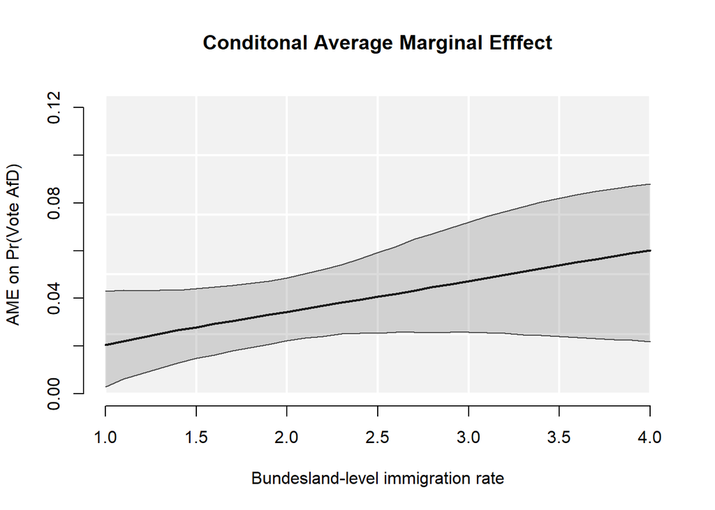

```r
# Plot
## Auxiliary objects
x_lines <-  seq(1, 4, .5)
y_lines <- seq(0, .125, .025)

## Canvas
plot(
  1,
  1,
  type = 'n',
  main = paste("Conditonal Average Marginal Efffect",
               sep = "\n"),
  axes = F,
  xlab = "Bundesland-level immigration rate",
  ylab = "AME on Pr(Vote AfD)",
  ylim = range(y_lines),
  xlim = range(x_lines)
)
axis(2, outer = FALSE)
axis(1)
rect(
  min(x_lines),
  min(y_lines),
  max(x_lines),
  max(y_lines),
  col = "gray95",
  border = NA
)
for (y in y_lines)
  segments(min(x_lines),
           y,
           max(x_lines),
           y,
           col = "white",
           lwd = 2)
for (x in x_lines)
  segments(x,
           min(y_lines),
           x,
           max(y_lines),
           col = "white",
           lwd = 2)

## Prediction
polygon(
  c(bl_immig_vals, rev(bl_immig_vals)),
  c(
    came[, 2],
    rev(came[, 3])
  ),
  col = adjustcolor("gray30", alpha.f = .2),
  border = NA
)
lines(bl_immig_vals,
      came[, 1],
      lty = 1,
      col = "gray10",
      lwd = 2)
lines(bl_immig_vals,
      came[, 2],
      lty = 1,
      col = "gray30")
lines(bl_immig_vals,
      came[ ,3],
      lty = 1,
      col = "gray30")
```

### 5.4 Follow-up

Suppose you have included this plot in a submission. Reviewer 2 remarks that it is interesting to see that the average effect of a one-point increase in anti-immigration preferences on AfD voting more than doubles along the scale of state-level immigration rates. However, they point out that the credible intervals at the two ends of the $x$-axis widely overlap and, therefore, wonder if the reported effect modification is truly systematic.

Modify the code you used to compute the conditional average effect to report the probability that the average effect of a one-point increase in anti-immigration preferences is greater when the state-level immigration rate is at its maximum as opposed to its minimum value.

```r
# Extract the model parameters
pars <- posterior::as_draws_matrix(rslogit_est)
beta <- posterior::subset_draws(pars, variable = "beta")
gamma <- posterior::subset_draws(pars, variable = "gamma")

# Extract the model matrices from standat_rslogit
X0 <- X1 <- standat_rslogit$x
Z0 <- Z1 <- standat_rslogit$z
X1[, "la_self"] <- X1[, "la_self"] + 1

# Get min/max values of bl_immig
bl_immig_vals <- range(standat_rslogit$z[, 1])

# Initialize container (for full posterior)
came <- array(NA, dim = c(length(bl_immig_vals), nrow(beta)))

# Start loop
for (i in seq_along(bl_immig_vals)) {
  # Manipulate z matrices
  Z0[, c("bl_immig", "bl_immig:la_self")] <-
    cbind(bl_immig_vals[i], bl_immig_vals[i] * X0[, "la_self"])
  Z1[, c("bl_immig", "bl_immig:la_self")] <-
    cbind(bl_immig_vals[i], bl_immig_vals[i] * X1[, "la_self"])

  # Get unit-specific linear predictors
  eta0 <- X0 %*% t(beta) + Z0 %*% t(gamma)
  eta1 <- X1 %*% t(beta) + Z1 %*% t(gamma)

  # Get unit-specific probabilities
  pi0 <- plogis(eta0)
  pi1 <- plogis(eta1)

  # Get unit-specific conditional marginal effects
  cme <- pi1 - pi0

  # Average across observations
  came[i, ] <- apply(cme, 2, mean)
}

# Report probability of interest
mean(came[2, ] > came[1, ])
```

```
## [1] 0.9185
```